# Practical Machine Learning

Olusoji Oluwafemi Daniel

Monday, March 16, 2015

### Summary

This work examines the relationship between variables measured from accelerometers on the belt, forearm, arm, and dumbell of 6 participants. They were asked to perform barbell lifts correctly and incorrectly in 5 different ways. Information about the dataset used for this work is available on [this wepage](http://groupware.les.inf.puc-rio.br/har). The training dataset can be downloaded via [this link](https://d396qusza40orc.cloudfront.net/predmachlearn/pml-training.csv) and the independent testing dataset is also available via [this link](https://d396qusza40orc.cloudfront.net/predmachlearn/pml-testing.csv). No preprocessing was carried out on the data since a function was written to remove the columns containing missing values. A train control option of *bootstraping* was used, this was done to help improve the prediction algorithm but this will underestimates the out of sample error rate of the model. The final model has an accuracy of about $99\%$.

### Reading in The Test and Training Data Sets

```r
setwd("~/practicalmachinedata")
#training dataset
training <- read.csv("pml-training.csv",header=T,blank.lines.skip=T,stringsAsFactors=F,na.strings="",skipNul=T)
#testing dataset
testing <- read.csv("pml-testing.csv",header=T,blank.lines.skip=T,na.strings="")
```

### Data Cleaning

After removing the first 5 variables, an identify function was written to help identify columns containing *NAs*, this columns are then removed from the training and testing dataset.

```r
training <- training[,c(-1,-2,-3,-4,-5)]
#
testing <- testing[,c(-1,-2,-3,-4,-5)]
#
training[,1] <- as.factor(training[,1])
#
testing[,1] <- as.factor(testing[,1])
#
training$classe <- as.factor(training$classe)
#Function ot identify bad columns
identify <- function(x)
  {
    if(!is.null(x) | is.data.frame(x) == TRUE)
      {
        vec <- c()
        for(i in 2:(length(x)-1))
          {
            a <- as.numeric(x[,i])
            a2 <- is.na(a)
            if(length(a[a2 == FALSE]) < (length(x[,i])/2))
              {
                vec <- c(vec,i)
              }
          }
        return(vec)
      }
    else stop("ERROR: Provide a data frame")
  }
#
bad_columns <- identify(training)
#
training <- training[,-bad_columns]
#
testing <- testing[,-bad_columns]
```

### Spilitting The Training Set

The training data set is further splitted into another training and testing dataset such that 70% of the data is contained in the new treaining set while the remaining 30% is assigned to the new testing dataset.

```r
inTrain <- createDataPartition(y=training$classe,p=0.7,list=FALSE)
training2 <- training[inTrain,]
testing2 <- training[-inTrain,]
```

### Exploratory Analysis

An attempt is made to fish out associations between variables in this study using scatterplots and using colours to distinguish classes.

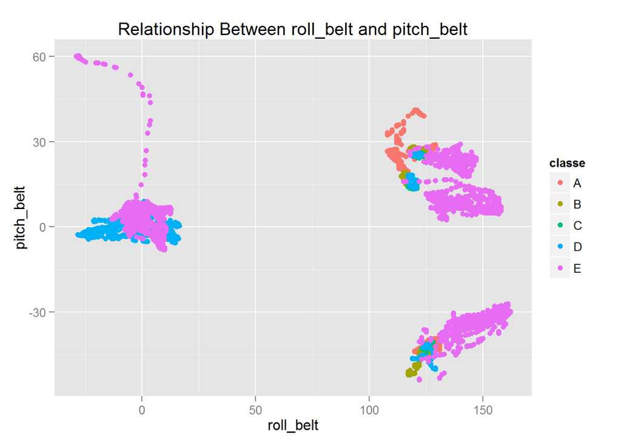

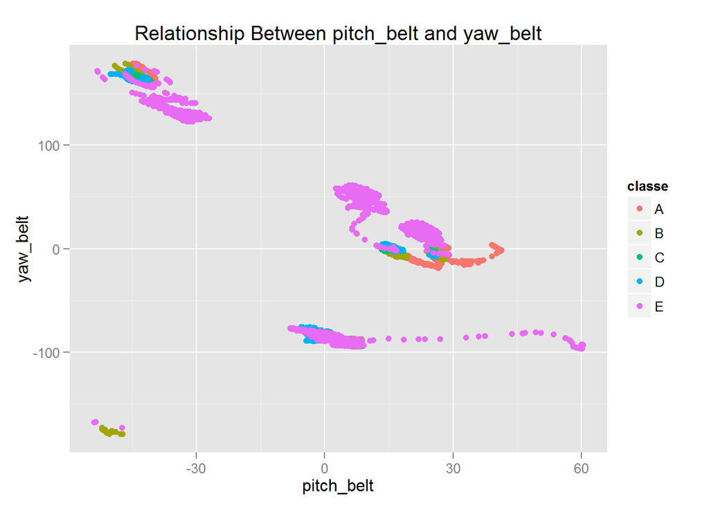

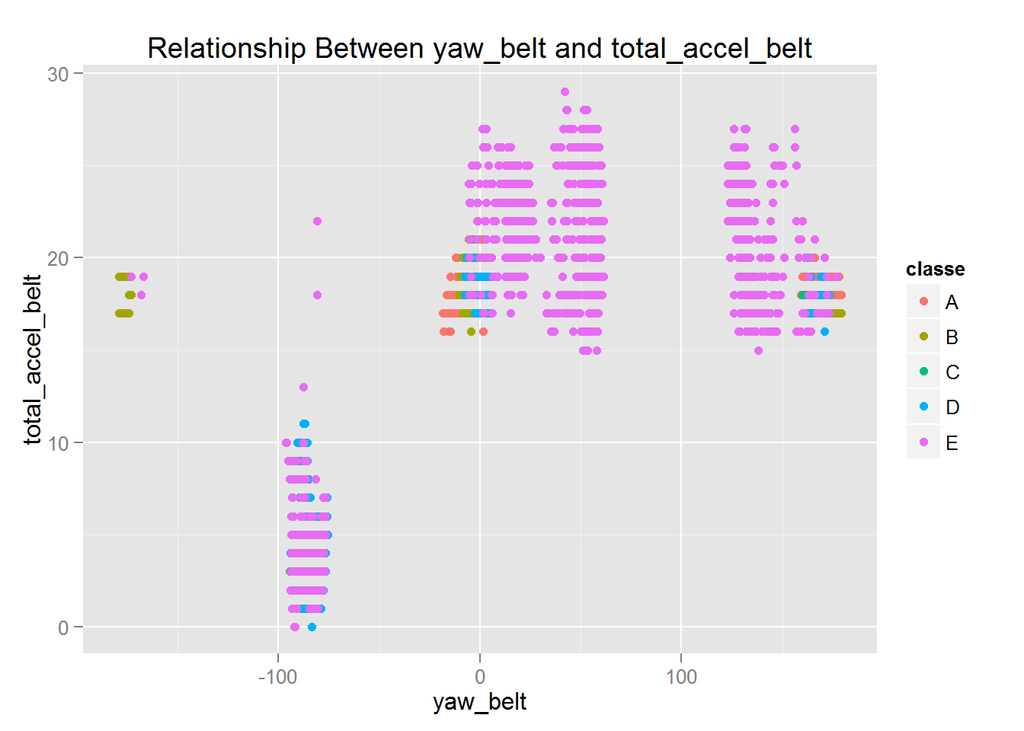

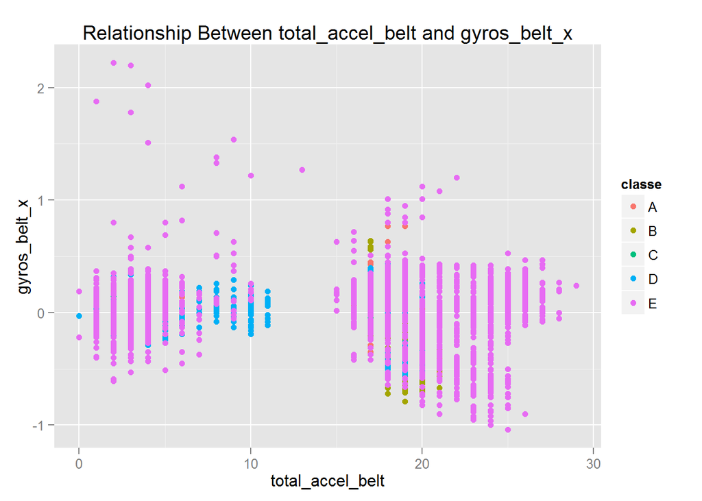

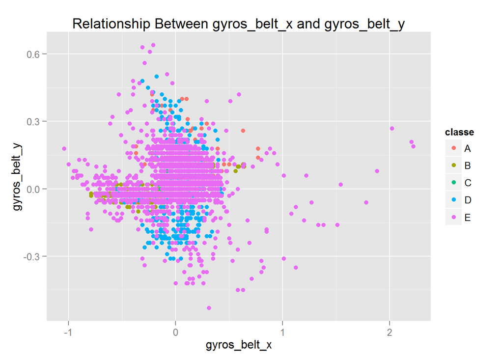

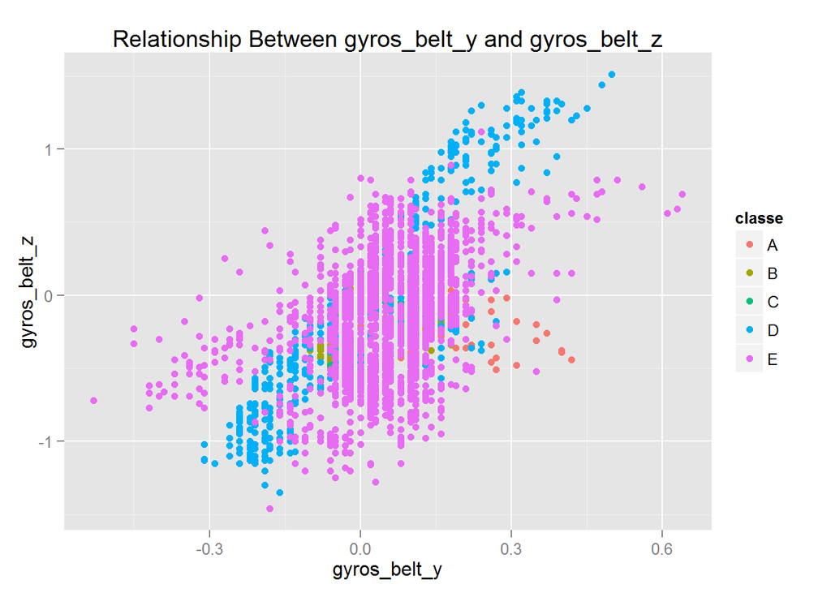

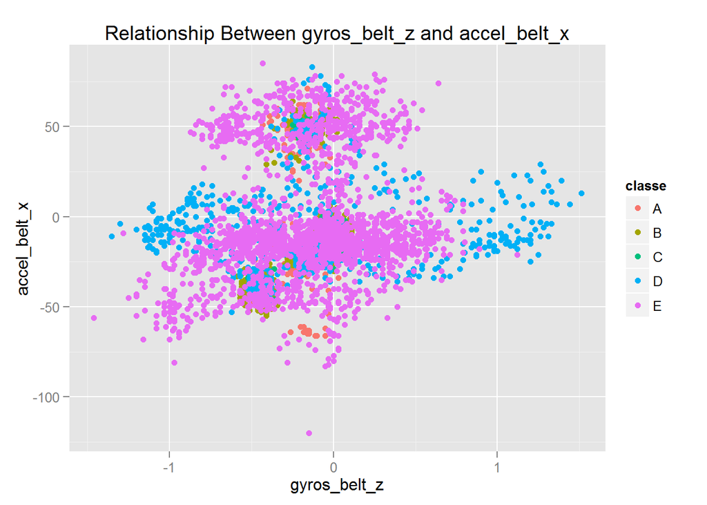

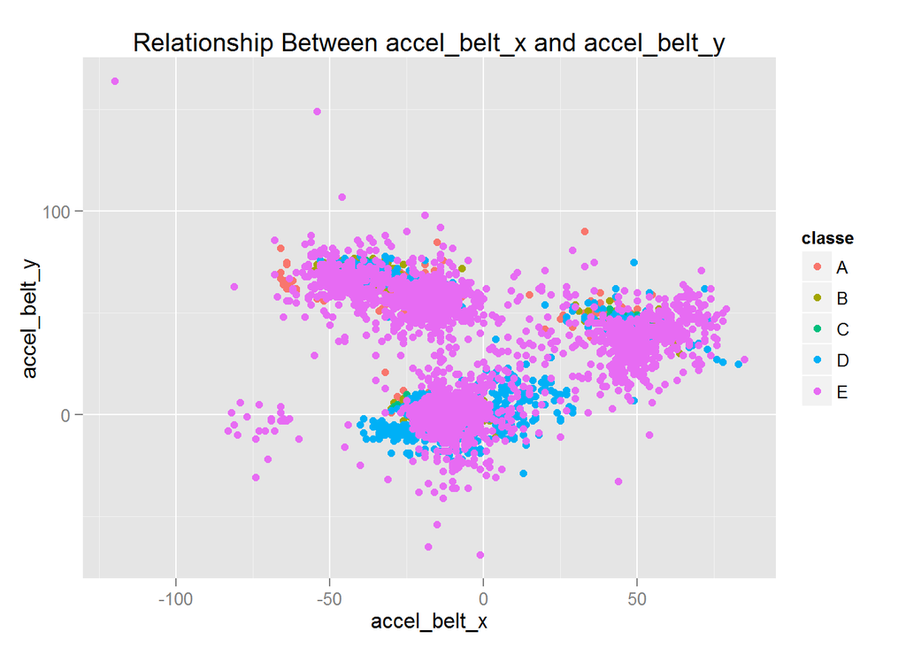

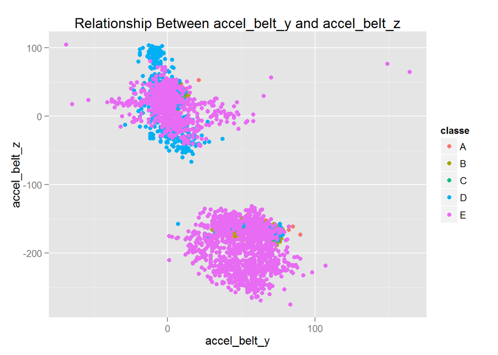

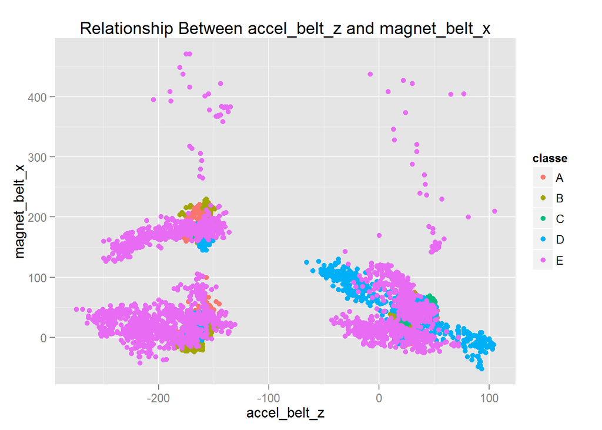

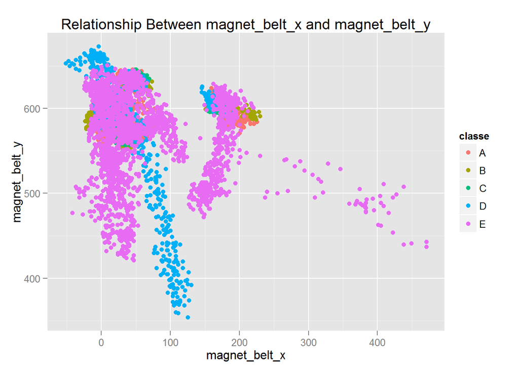

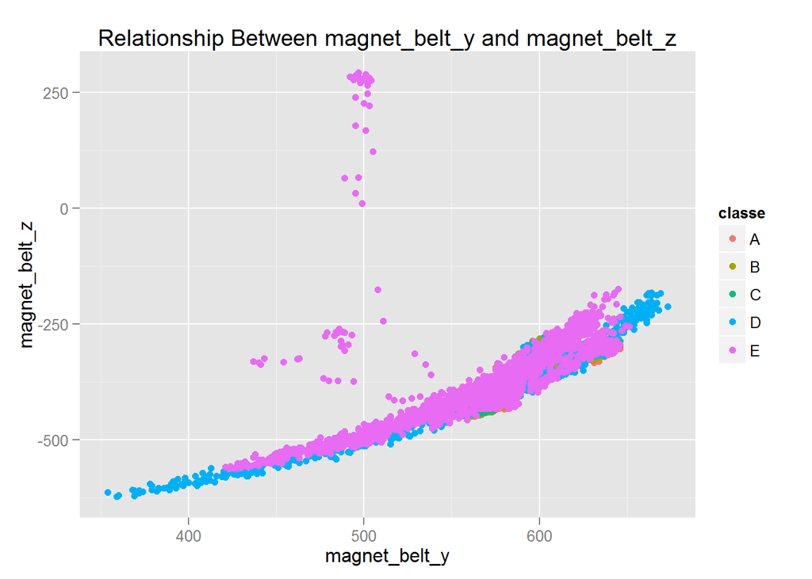

[39 more figures not shown]

```r
for(i in 3:53){
    plots <- qplot(training2[,i],training2[,i+1],data=training2,colour=classe,xlab=names(training2)[i],ylab=names(training2)[i+1],main=paste("Relationship Between",names(training2)[i], "and", names(training2)[i+1]))
    print(plots)
}
```

Most of the plots shows varying degree of relationship by class between variables under study. In some plots, it is quite clear that the data can be divided into groups with relationship existing between these groups.

### Model Training

```r
mod1 <- train(classe~.,data=training2,method="gbm",metric="Accuracy",trControl=trainControl(method="boot",number=2),verbose=F)
print(mod1$finalModel)
```

```
## A gradient boosted model with multinomial loss function.
## 150 iterations were performed.
## There were 54 predictors of which 44 had non-zero influence.
```

### Prediction

```r
pred1 <- predict(mod1,newdata=testing2)
confusionMatrix(pred1,testing2$classe)
```

```
## Confusion Matrix and Statistics
##
##           Reference
## Prediction    A    B    C    D    E
##          A 1673   14    0    0    0
##          B    1 1112   10    2    1
##          C    0   10 1016   13    1
##          D    0    3    0  949    7
##          E    0    0    0    0 1073
##
## Overall Statistics
##
##                Accuracy : 0.9895
##                  95% CI : (0.9865, 0.9919)
##     No Information Rate : 0.2845
##     P-Value [Acc > NIR] : < 2.2e-16
##
##                   Kappa : 0.9867
##  Mcnemar's Test P-Value : NA
##
## Statistics by Class:
##
##                      Class: A Class: B Class: C Class: D Class: E
## Sensitivity            0.9994   0.9763   0.9903   0.9844   0.9917
## Specificity            0.9967   0.9971   0.9951   0.9980   1.0000
## Pos Pred Value         0.9917   0.9876   0.9769   0.9896   1.0000
## Neg Pred Value         0.9998   0.9943   0.9979   0.9970   0.9981
## Prevalence             0.2845   0.1935   0.1743   0.1638   0.1839
## Detection Rate         0.2843   0.1890   0.1726   0.1613   0.1823
## Detection Prevalence   0.2867   0.1913   0.1767   0.1630   0.1823
## Balanced Accuracy      0.9980   0.9867   0.9927   0.9912   0.9958
```

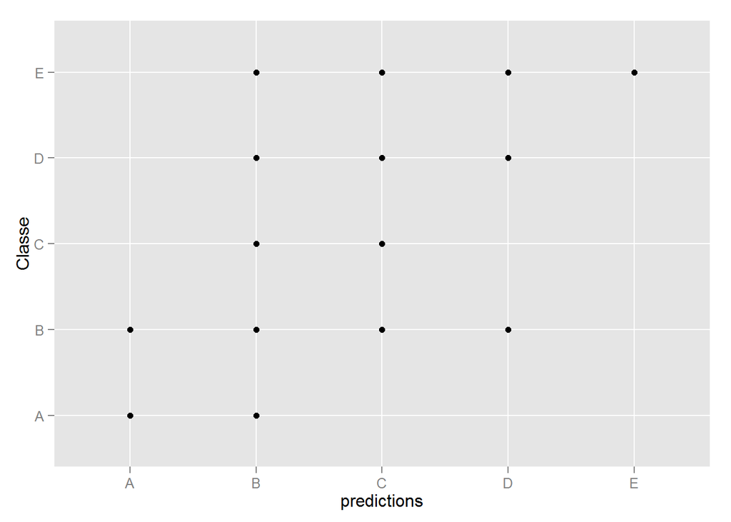

```r
qplot(pred1,classe,data=testing2,xlab="predictions",ylab="Classe")
```

```r
pred2 <- predict(mod1,newdata=testing)
pred2
```

```
##  [1] B A B A A E D B A A B C B A E E A B B B
## Levels: A B C D E
```

```r
pml_write_files = function(x){
    n = length(x)
    for(i in 1:n){
        filename = paste0("problem_id_",i,".txt")
        write.table(x[i],file=filename,quote=FALSE,row.names=FALSE,col.names=FALSE)
    }
}
pml_write_files(pred2)
```

### Plot Showing Model Accuracy

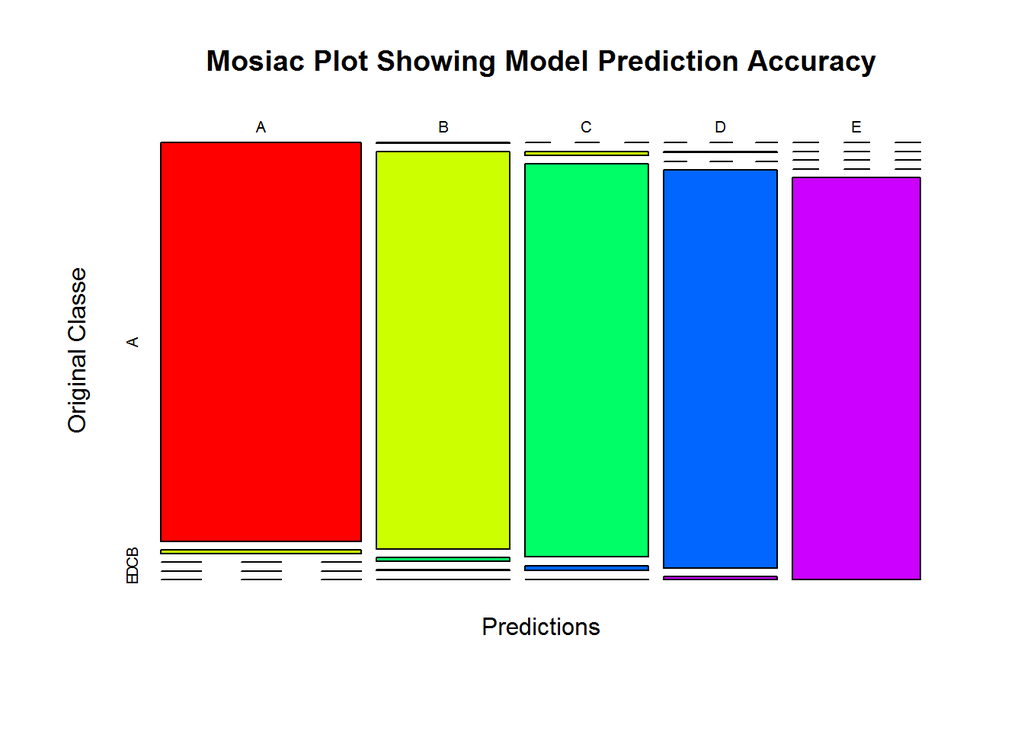

```r
plot(xtabs(~pred1+testing2$classe),col=rainbow(5),xlab="Predictions",ylab="Original Classe",main="Mosiac Plot Showing Model Prediction Accuracy")
```

The plot shows that most of the class was correctly predicted **C** was the level that was wrongly predicted the most.